# STAT650 FINAL -734004713

## STAT 650 - Final Project

## LIFE EXPECTANCY DATA

*Developed by (Name: Hasitha Varada - 734004713)*

## Introduction

A person's average life expectancy is determined by a statistical calculation that takes into account their current mortality rate as well as other demographic characteristics. It offers information on the duration and quality of life and is a crucial measure of the general health and well-being of a population. Years are frequently used to describe life expectancy, which is determined for various demographic groupings, geographical areas, and nations. Life expectancy is influenced by a number of elements, which may be roughly classified into social, economic, environmental, and healthcare-related aspects. Living circumstances, sanitation, and pollution exposure are examples of environmental elements; income, education, and resource accessibility are examples of social and economic factors. Preventive measures, illness treatment, and the availability and caliber of healthcare services are all considered healthcare considerations.

**GOAL** - A key indicator of the general well-being and wealth of a society is life expectancy that is a crucial parameter that measures the typical number of years a person can expect to live. Our goal is to pinpoint the primary factors that have a major influence on life expectancy using regression analysis and statistical modeling. 1) There is a significant association between alcohol consumption and mortality rates among adults. 2) The average BMI of the population is positively correlated with life expectancy. 3) The life expectancy of people is influenced by a combination of socio-economic factors, health-related indicators, and vaccination coverage

**OBJECTIVE** - Our main Objective is to reveal the complex connections and patterns within the dataset. We intend to identify the influence of various variables by utilizing statistcal approaches, correlation, data visualization and to conduct a comprehensive analysis of life expectancy data, exploring the relationships between various socio-economic, environmental, and healthcare factors.

**BACKGROUND** - This research is important because it adds to the body of knowledge already available on life expectancy and because it has applications for policymakers who want to create focused initiatives that will enhance population health outcomes. Understanding the factors that affect life expectancy can help us develop public health initiatives that are more successful.My main interest in health care domain led me to take this dataset to know more about the cause of deaths in the world.

## Data Description

Our data source is used from kaggle. The selected dataset is in csv format.https://www.kaggle.com/datasets/kumarajarshi/life-expectancy-who/code

**Data Collection**

Variables

1.Status - Nominal Categorical Variable

2.Country - Nominal Categorical Variable

3.Adult Mortality - Discrete Quantitative Variable

4.Infant Deaths - Discrete Quantitative Variable

5.Alcohol - Continuous Quantitative Variable

6.BMI - Continuous Quantitative Variable

7.Polio - Discrete Quantitative Variable

8.HIV/AIDS - Continuous Quantitative Variable

9.GDP - Continuous Quantitative Variable

10.Under five- deaths - Discrete Quantitative Variable

11.Population - Discrete Quantitative Variable

12.Schooling - Continuous Quantitative Variable

13.Life Expectancy Data - Continuous Quantitative Variable

14.Income composition of resources - Continuous Quantitative Variable

We have collected the data and imported the libraries necessary for the EDA .

## Data Preprocessing:

By importing the data we have got 5 rows * 22 columns

By checking the **shape** of the data we got output of *(2938, 22)*

By checking the **types** of data = dtypes: float64(16), int64(4), object(2) memory usage: 505.1+ KB

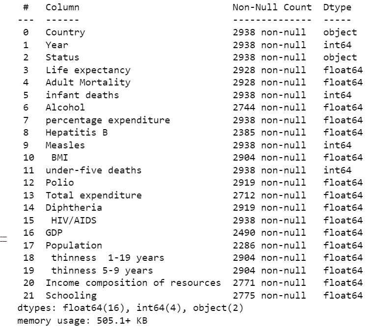

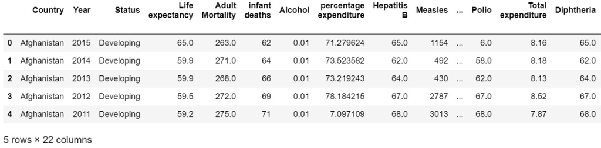

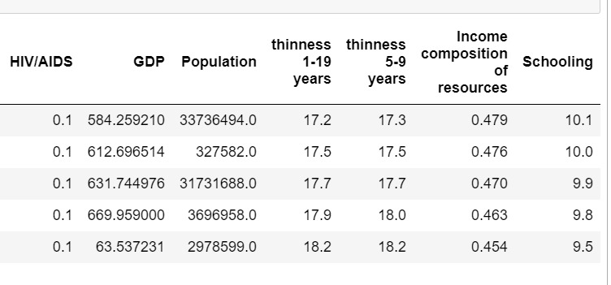

**By checking unique values of different variables**

**Population** = [33736494. 327582. 31731688. ... 125525. 12366165. 12222251.]

It represents a series of distinct population values in the DataFrame's "Population" column. For every integer in the array, there is a unique population value associated with that column. With numbers ranging from 33 to 1.29e+09 (1.29 billion), the average population is 1.28e+07 (12.8 million).

**Alcohol** = [0.01 0.03 0.02 ... 2.44 3.56 4.57]

It represents a sequence of unique alcohol consumption values in the 'Alcohol' column of the DataFrame. Each number in the array is a distinct alcohol consumption value found in that column.The average amount of alcohol consumed ranges from 0.01 to 17.87, with a mean of roughly 4.60. The standard deviation of 4.05 indicates that patters of alcohol intake can vary.

**Adult Mortality**

It represents a sequence of unique adult mortality values in the 'Adult Mortality' column of the DataFrame. The adult mortality rate ranges from 1 to 723, with an average of about 164.80. The distribution has a standard deviation that is rather high (124.29), indicating that adult death rates may vary.

Let's make a sub-dataset from our original dataset for our research objective, goals by dropping unnecessary variables and use this for further process.

**Missing values**

There are missing values in variables like alcohol, population, polio, BMI, Schooling.

We have handled the new dataset by checking if they are less than 40%

we are handling missing values for BMI- (2727, 14)

we are handling missing values for Polio- (2108, 14)

we are handling missing values for Schooling- (2108, 14)

**Checking Outliers**

Adult Mortality no of outliers = : 66 and we removed it.

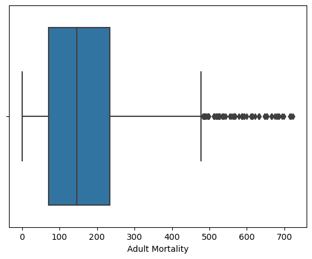

Under-5 deaths - no of outliers = : 209 we removed it.

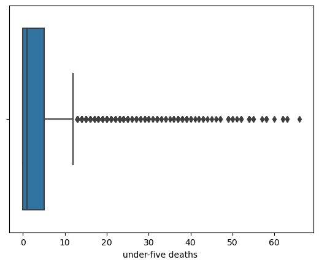

Life expectancy no of outliers = : 5 and we removed it.

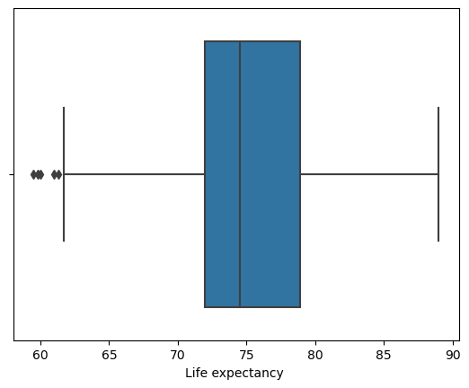

## Exploratory Data Analysis

## Univariate analysis

**Histogram for life expectancy of people**

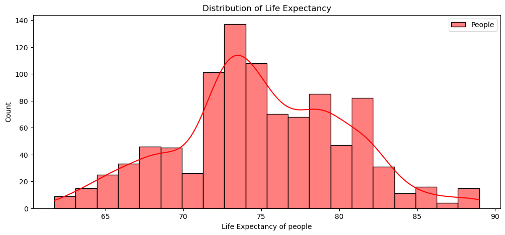

**Plot the countplot of status**

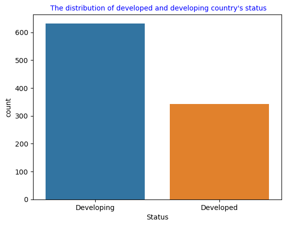

**Plot the distplot of alcohol variable**

The distplot shows information about the central tendency, spread, and distributional shape of the values in the 'Alcohol' variable. From this distribution plot we can infer that the range of alcohol has increased from 0.08% to highest 0.12%. The density is varying here and there at 0.04%.

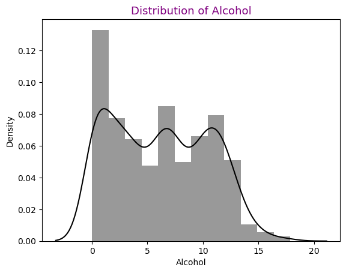

**Plot the distplot of Polio variable**

The histogram component of the distplot visualizes the frequency or count of different ranges (bins) of Polio values. From this distribution plot we can infer that the range of Polio or the rate of people died due to polio vaccine has increased from 0 to highest 0.20 density.The density is varying drastically so we can't take average here. The peak is attained at 0.10.

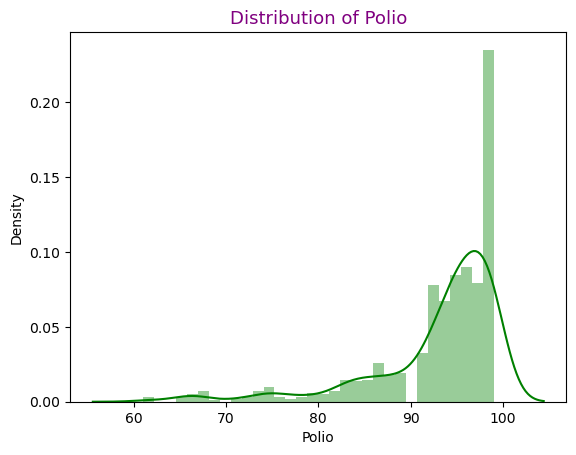

**Plot the distplot of schooling variable**

The histogram component of the distplot visualizes the frequency or count of different ranges (bins) of schooling values. The KDE overlay smoothens the histogram, providing an estimate of the probability density function for the variable. From this distribution plot we can infer the range of students who have completed schooling and we can see the drastic change as the graph increased and again decreased completely to 22.5. The highest point it reached was more than 0.175.

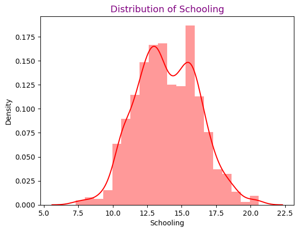

**Histogram for the distribution of population**

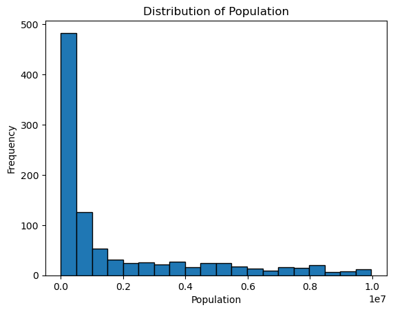

## Bi-variate analysis

**Scatter plot: Adult Mortality vs Infant and under-5 children Deaths**

The scatter plot visually compares "Adult Mortality" with the number of "Infant Deaths" and "Under-Five Deaths" for each data point. It suggests a link between adult mortality and the incidence of baby and child fatalities. In other words, if adult mortality rises, baby and child fatalities likely to rise as well.

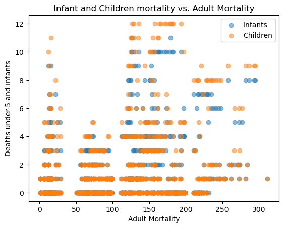

**Plotting a bar graph for showing average adult mortality rate of people in all countries**

Using a bar graph we have shown the average mortality rate of people with regarding to the countries. The bar graph displays the average adult mortality rate for each country, providing a visual comparison. The x-axis represents different countries, and the y-axis represents the average adult mortality rate. From this we infer that the highest performer is Kazhakasthan and the lowest is country Tunisia. The average adult morality rate kept fluctuatingbetween 50 and 250.

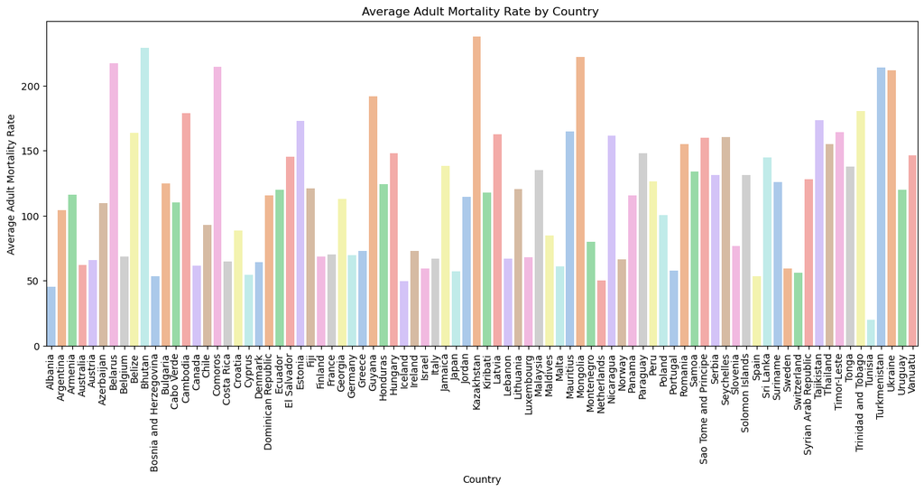

**Histograms for all the variables**

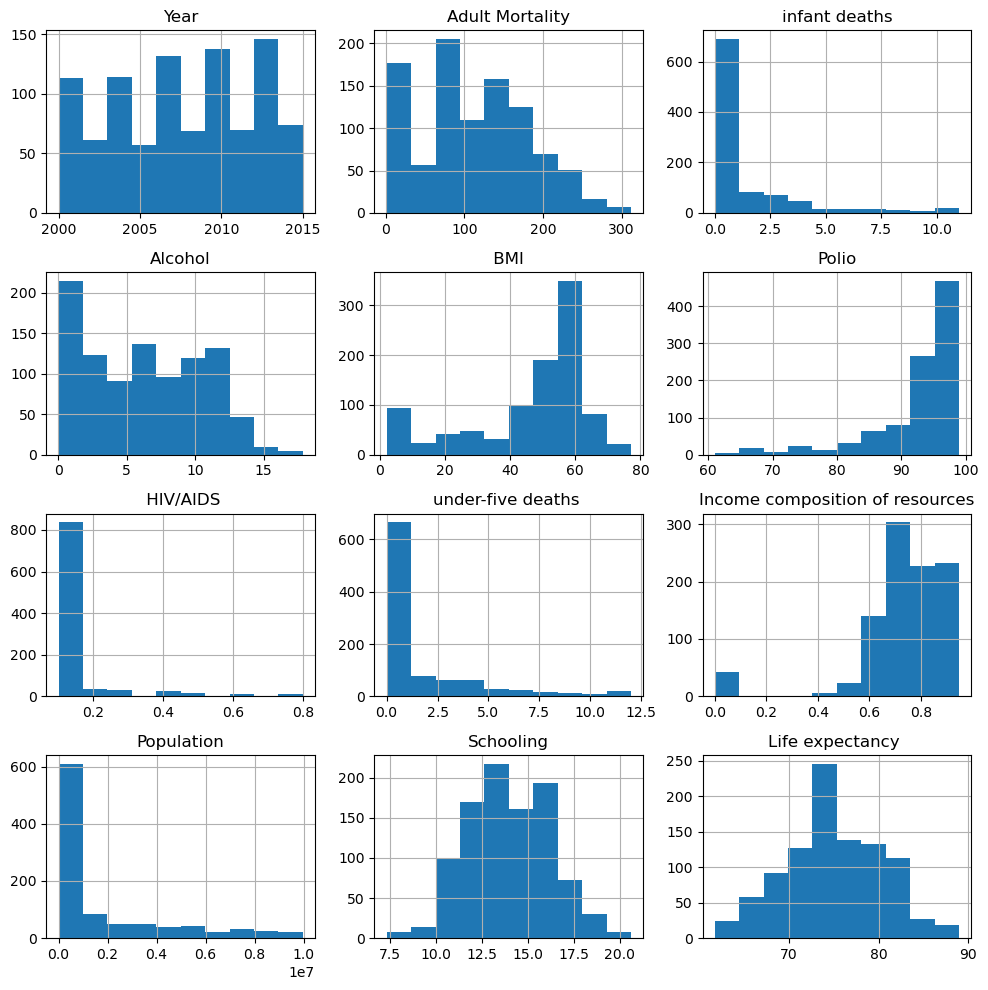

**Scatter plot: Life expectancy vs HIV**

For every data point, the scatter plot shows the relationship between "Life Expectancy" and "HIV/AIDS" graphically. The x-coordinate in the plot indicates the prevalence of HIV/AIDS, while the y-coordinate indicates life expectancy. Each point in the plot represents a nation or observation. Now as we are doing for the bivariate analysis we are comparing the life expectancy to the HIV disease through which many people died. When compared among people we can say that the life expectancy of people have decreased because of HIV and it was of same level and did not increase or decrease drastically.

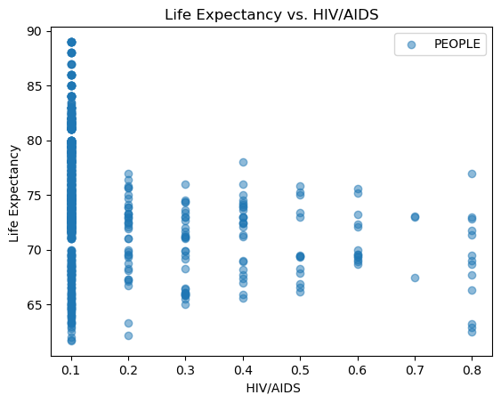

## Multivariate analysis

**Correlation matrix for all the variables**

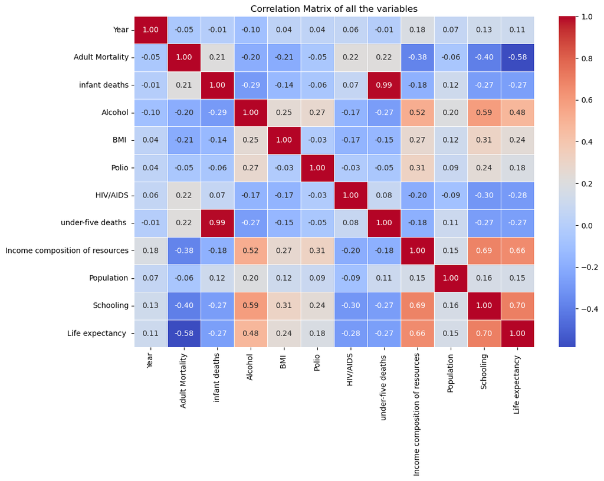

**Through correlation between the life expectancy of people and their death rates**

The pair plot visually represents the relationships between the selected attributes ('Life expectancy' and 'Adult Mortality'). Scatter plots on the upper and lower triangles show bivariate relationships where it keeps varying between 0-300 while histograms on the diagonal show the univariate distributions. From this heatmap we can get the correlation between these two variables. Comparing different variables we can infer that red ones are all correlated.

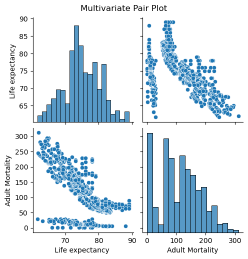

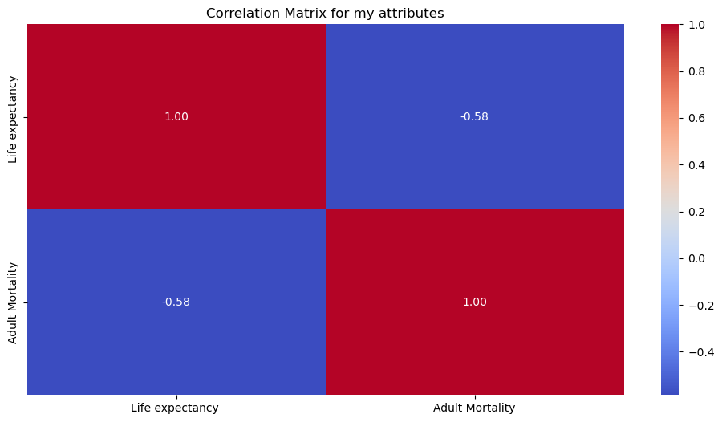

**Heatmap for finding correlation between selected variables ['BMI', 'HIV', 'Polio', 'Alcohol']**

The correlation matrix is shown in a heatmap that is tailored to the attributes that have been chosen (BMI, HIV/AIDS, Polio, Alcohol). The annotations and color map 'coolwarm' offer information about the direction and strength of the correlations. From this heatmap we can get the correlation matrix in a visualized mode. Comparing different variables we can infer that red ones are all correlated and the blue ones are less than 1 and are negatively correlated. There are many neutral non correlated variables.

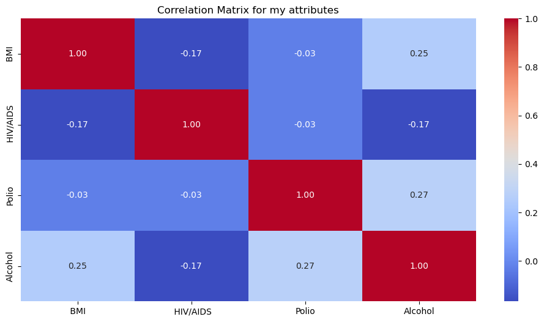

## Three different Hypotheses and two of them can be shown during Exploratory Data Analysis

*1)There is a significant association between alcohol consumption and mortality rates among adults.*

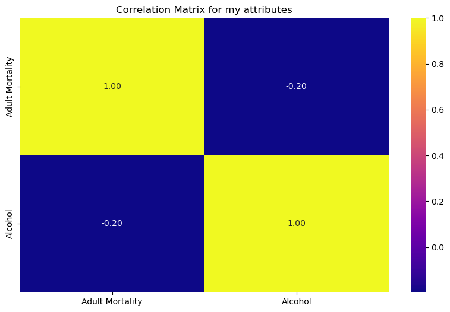

*2)The average BMI of the population is positively correlated with life expectancy.*

The correlation between 'BMI' and 'Life expectancy' is 0.24. A weak positive correlation between "BMI" and "life expectancy" is indicated by the positive correlation coefficient of 0.24. This indicates that there is a small tendency for life expectancy to rise in combination with an increase in body mass index (BMI). The correlation is weak, though, and life expectancy is probably influenced by other factors to a greater extent.

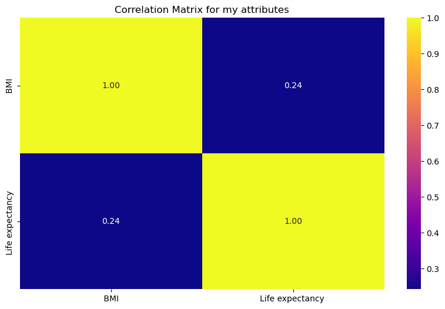

**FOR THIRD HYPOTHESES WE WILL USE REGRESSION MODELS**

*3)The life expectancy of people is influenced by a combination of socio-economic factors, health-related indicators, and vaccination coverage*

According to this hypothesis, life expectancy is a complicated result that is influenced by a number of variables. Modeling life expectancy as a function of several independent variables, such as ' HIV/AIDS', 'Income composition of resources', 'Adult Mortality', ' BMI ', 'under-five deaths ' and other pertinent variables, is possible with multiple linear regression.

**Dependent Variable**: 'Life expectancy'

**Independent variable**: ' HIV/AIDS', 'Income composition of resources', 'Adult Mortality', ' BMI ', 'under-five deaths '

## STATISTICAL METHODS

**T-TEST**

We have done T-test to compare the means of two groups. We have chose the variables need for our hypothese and for regression analysis over here. They are status and life expectancy, to check that they both are significantly different. We have infered that one set og group of countries are still under development and another part of group are well developed. This might affect the life expectancy.

T-statistic: 21.988117605025288

P-value: 5.241763508367791e-84

As a result we have reject the null hypothesis. There is significant difference.

**I have use used 4 regression models for my dataset**

**a. Multiple Linear Regression**

**b. Lasso Regression**

**c. Ridge Regression**

**d. Elastic Net Regression**

## MODELLING TECHNIQUES

**MODEL FITTING**

**Justification:** Relevant characteristics (predictors) like ' HIV/AIDS', 'Income composition of resources', 'Adult Mortality', ' BMI ', 'under-five deaths' are used as independent variables in the models' fitting process, while Life expectancy data serves as the dependent variable.

**Training and Testing Data:** To assess model performance, the dataset is divided into training and testing sets.

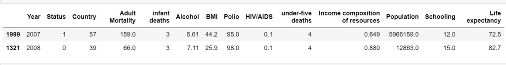

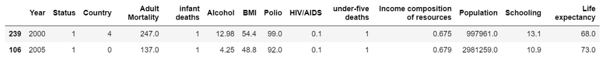

**Regularization:** Regularization techniques (Lasso, Ridge, Elastic Net) are employed to prevent overfitting by penalizing large coefficients. The regularization strength (alpha) is tuned for optimal performance.

## REASONS FOR SELECTION

**1. MULTIPLE LINEAR REGRESSION:** When dealing with factors influencing life expectancy, linear regression is useful. It gives information on the unique contributions made by every predictor.

**2.RIDGE REGRESSION:** This method stabilizes the model by avoiding excessively high coefficients, making it useful when multicollinearity among the predictors is suspected.

**3.LASSO REGRESSION:** Excellent for feature selection, since it aids in determining the key variables that have the greatest influence on life expectancy.

**4.ELASTIC NET REGRESSION:** An optimal option for utilizing both Lasso's feature selection powers and Ridge's advantages in coefficient stability.

## Model Evaluation and Selection

Regression approach: **Multiple Linear Regression**

Linearity: In my dataset it indicates that the response variable and the predictors have a linear relationship. They are linear. Residuals are independent of each other. Residuals are normally distributed.

Regression approach: **Ridge Regression**

We can assume for this regression that the default alpha value should be 1. The tolerance statistic is the reciprocal of the VIF. Low tolerance values (< 0.1) indicate a problematic level of multicollinearity.

Regression approach: **Lasso Regression**

The relationship between the independent variables and the dependent variable is linear. We can assume for this regression that the default alpha value should be 1. The tolerance statistic is the reciprocal of the VIF. Low tolerance values (< 0.1) indicate a problematic level of multicollinearity. Residuals are independent of each other.

Regression approach: **Elasticnet Regression**

We can assume that the variance of residuals is constant across all levels of the independent variables. In other words, the spread of residualsare consistent. Similar to Lasso, this encourages sparsity in the model by penalizing some regression coefficients to exactly zero.

**IMPLEMENTATION OF MODELS**

**Linear Regression:**

R-squared (R2): 0.4797813798878948

Mean Squared Error: 15.582571770841325

Root Mean Squared Error: 3.9474766333496296

Mean Absolute Error: 2.943524776013167

The R-squared value of 0.48 indicates that the model explains a moderate amount of the variability in the dependent variable.

On average, this model's predictions are off by approximately 2.94 units in the same scale as the dependent variable.

**Ridge Regression:**

Ridge CV Model Mean Squared Error: 15.600950316094979

Best Alpha after Cross Validation : 0.4552935074866948

Mean Squared Error: 22.753070107554628

Root Mean Squared Error: 4.770017830947242

Mean Absolute Error: 3.5408274237391044

R2: 0.24039684150115204

This is the mean squared error of the Ridge regression model after cross-validation. It indicates the average squared difference between the predicted and actual values, and a lower value is desirable. The MSE is 15.60.

R-squared measures the proportion of the variance in the dependent variable that is predictable from the independent variables. R-squared is 0.2404, indicating that about 24% of the variability in the dependent variable.

**Lasso Regression**

Mean Squared Error: 16.501150276010712

Root Mean Squared Error: 4.062160789039586

Mean Absolute Error: 3.0301120674742834

R2: 0.44911496297986864

MSE is the average of the squared differences between predicted and actual values. It provides a measure of the average squared error. The MSE is 16.50, indicating the average squared difference between predicted and actual values.

R-squared measures the proportion of the variance in the dependent variable that is explained by the independent variables. R-squared is 0.4491, indicating that approximately 44.91% of the variability in the dependent variable is explained by model.

**Elasticnet Regression**

Best alpha: 0.1 Best l1 ratio: 0.5 ElasticNet(alpha=0.1)

Mean Squared Error: 19.964476408538058

Root Mean Squared Error: 4.468162531571346

Mean Absolute Error: 3.2848263681720486

R2: 0.33349305100299254

R-squared calculates the percentage of the dependent variable's variation that can be accounted for by the independent variables. R-squared is 0.3335, that the ElasticNet model accounts for around 33.35% of the variability in the dependent variable.

**Testing model assumptions for their linearity**

1.LINEAR REGRESSION

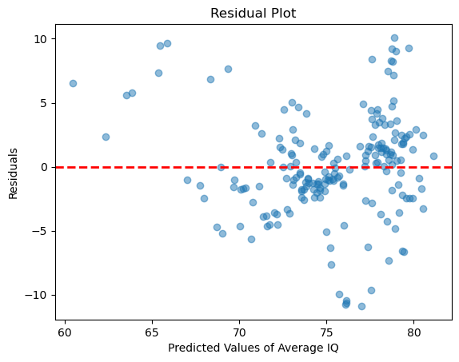

2.RIDGE REGRESSION

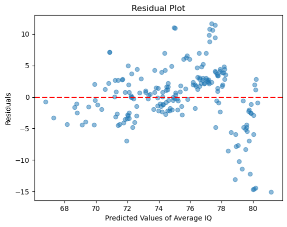

3.LASSO REGRESSION

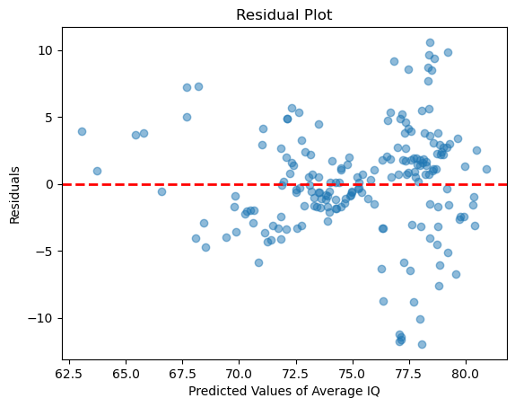

4.ELASTICNET REGRESSION

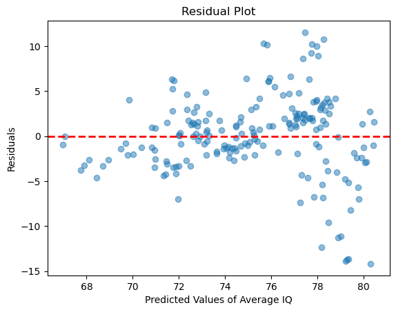

## Model Comparison

After developing the model, I have evaluated its performance using appropriate metrics. I have included R-squared, mean squared error, root mean squared error. I have compared the metrics.

**By comparing metrics MSE**

Mean Squared Error:

Linear Regression: 15.582571770841325

Ridge Regression: 22.753070107554628

Lasso Regression: 16.501150276010712

Elastinet Regression: 19.964476408538058

**The model with the lowest average squared difference (MSE) between the predicted and actual values is linear regression. In terms of MSE, it performs better.**

**By comparing metrics of RMSE**

Root Mean Squared Error:

Simple Linear Regression: 3.9474766333496296

Ridge Regression: 4.770017830947242

Lasso Regression: 4.062160789039586

Elastinet Regression: 4.468162531571346

**Linear Regression has the lowest RMSE, indicating the smallest average magnitude of errors. It performs better in terms of RMSE**

**By comparing metrics of MAE**

Mean Absolute Error:

Simple Linear Regression: 2.943524776013167

Ridge Regression: 3.5408274237391044

Lasso Regression: 3.0301120674742834

Elastinet Regression: 3.2848263681720486

**Linear Regression has the lowest MAE, indicating the smallest average absolute difference between predicted and actual values. It performs better in terms of MAE**

Across all three metrics (MSE, RMSE, MAE), Linear Regression consistently performs the best among the models compared.

In this instance, regularized models (such as Ridge, Lasso, and ElasticNet) have more errors than Linear Regression because they impose penalties for model complexity. A trade-off between simplicity and complexity may need to be made when selecting amongst these models.

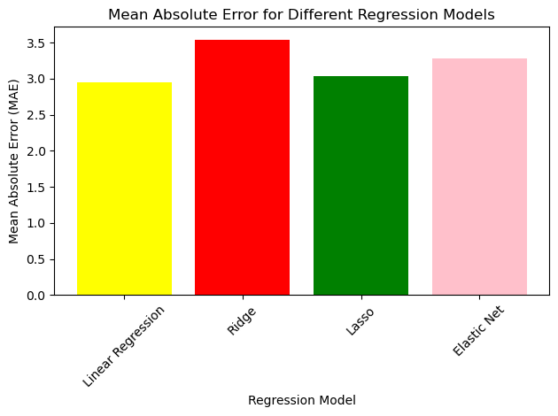

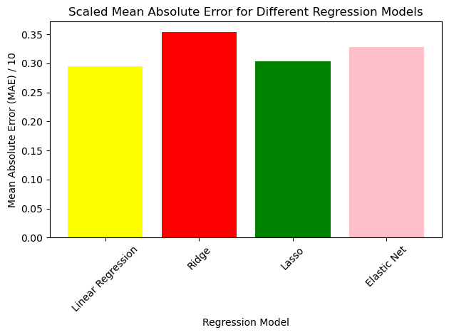

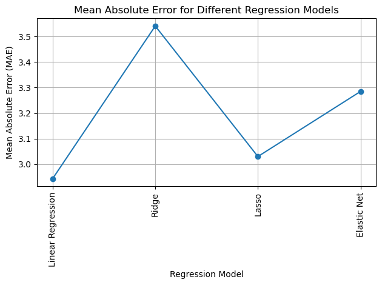

## Model Improvement

**Hyperparameter tuning** for linear regression typically involves tuning the regularization strength (alpha) in models like Ridge or Lasso.

After hyperparamater tuning:

Ridge MSE: 15.628590025999792

Lasso MSE: 15.631335078226114

Comparable Performance: Ridge and Lasso function similarly, and there may not be a big difference in their forecasting accuracy.

Impact of Regularization: Preventing overfitting and offering a fair balance between bias and variance are probably achieved by the regularization strength (alpha) selected during hyperparameter tuning. In our dataset

## Results and Interpretation

**Performance:**

In comparing the performance of the regression models applied to the life expectancy data, three key evaluation metrics were considered: Mean Squared Error (MSE), Root Mean Squared Error (RMSE), and Mean Absolute Error (MAE). The models under consideration were Simple Linear Regression, Ridge Regression, Lasso Regression, and ElasticNet Regression.

The Linear Regression model consistently outperformed the regularized models across all three metrics. It exhibited the lowest MSE, RMSE, and MAE, indicating smaller average prediction errors and better overall accuracy. This suggests that, the linear model without regularization provided a more effective representation of the relationship between predictor variables and life expectancy.

**Statistical Significane**

This comparison's t-statistic was determined to be 21.99, and the corresponding p-value was around 5.24e-84. We rejected the null hypothesis because the p-value was very low—much less than the typically accepted significance criterion of 0.05. This suggests that the two sets of nations' life expectancies differ statistically significantly. The conclusion is that life expectancy is significantly influenced by a country's development level, as shown by the 'level' variable. The results of the subsequent regression analyses allowed for a more nuanced investigation of the relationships between life expectancy and multiple predictors, taking into account both statistical and practical significance. The t-test revealed a significant difference in life expectancy between developing and developed countries.

**Interpret coefficients of significant predictors**

The effect of 'Adult Mortality' on life expectancy might be different at different levels of 'BMI' or 'HIV/AIDS'. If the coefficient is 0.5, it means that for every one-unit increase in the 'Income composition of resources', life expectancy is expected to increase by 0.5 units, holding other variables constant.

Higher adult mortality rates are associated with lower life expectancy, which is an expected and logical relationship. This suggests that addressing adult mortality is crucial for improving life expectancy.

A higher BMI may be associated with better nutritional status, contributing to improved health and potentially higher life expectancy. Higher under-five deaths are negatively associated with life expectancy, emphasizing the importance of addressing child mortality for overall population health.

## Conclusion

The significance of features:

Life Expectancy and Development Status:

A substantial difference was found when the life expectancy means of industrialized and developing nations were compared using a t-test.Life expectancy is strongly influenced by a nation's level of development, indicating that socioeconomic issues are important.

Model Execution:

Predictive Knowledge:

Based on the chosen features, the project offers prediction algorithms that can calculate life expectancy. Policymakers, medical professionals, and academics may all benefit from using these models to comprehend and predict changes in life expectancy.

**limitations of the project**

**Data Quality:**

The dataset I have chosen has many missing values and is very tough to remove them. Potentially they affect the reliability of the results. Future research should involve more extensive data cleaning and imputation methods to enhance data quality.

**Model Complexity:**

The regression models used are simplified representations of complex interactions. Future research could explore advanced machine learning models or ensemble techniques to capture intricate relationships more accurately.

**Limited Time Frame:**

This analysis is confined to a specific time frame, and life expectancy trends might evolve over time. Future research could explore longitudinal data to capture temporal variations and trends.

**To overcome this limitation I would recommend:**

**Intercultural Research:**

Investigate cross-cultural differences by carrying out in-depth research on certain areas or nations, taking into account distinctive cultural and socioeconomic factors that influence life expectancy.

**Verification and Extrapolation:**

Test the created models on external datasets to improve the models' generalizability and determine how reliable the results are for a range of population types.

## Reference and Appendix

- https://www.scaler.com/topics/pandas/eda-in-pandas/
- https://towardsdatascience.com/exploratory-data-analysis-eda-python-87178e35b14
- https://www.numpyninja.com/post/exploratory-data-analysis-eda-using-python-part-1
- https://www.justintodata.com/how-to-use-python-seaborn-for-exploratory-data-analysis/
- https://www.kaggle.com/code/taolearnstolearn/eda-with-bar-plot
- https://r4ds.had.co.nz/exploratory-data-analysis.html
- https://stat.ethz.ch/R-manual/R-devel/library/stats/html/00Index.html
- https://scikit-learn.org/stable/modules/generated/sklearn.linear_model.LinearRegression.html
- https://www.sharpsightlabs.com/blog/scikit-train_test_split/
- https://scikit-learn.org/stable/modules/generated/sklearn.metrics.mean_squared_error.html
- https://towardsdatascience.com/model-evaluation-in-scikit-learn-abce32ee4a99
- https://www.geeksforgeeks.org/data-pre-processing-wit-sklearn-using-standard-and-minmax-scaler/
- https://www.geeksforgeeks.org/ml-label-encoding-of-datasets-in-python/
- https://scikit-learn.org/stable/modules/generated/sklearn.linear_model.ElasticNet.html
- https://scikit-learn.org/stable/modules/generated/sklearn.model_selection.GridSearchCV.html

```python
'''# Import libraries for EDA
import pandas as pd
import numpy as np
import seaborn as sns
import matplotlib.pyplot as plt
%matplotlib inline
# Import your data easy to read
dframe = pd.read_csv("C:/Users/19793/Documents/stat 650 final/Life_expectancy_data.csv")
dframe.head()
dframe.columns
# 1. Check data dimension by using .shape
dframe.shape
# 2. Check types of data by .info() ; .dtype
dframe.info()
# 3. For quantitative variable, generate a table for the count, mean, standard deviation, minimum and maximum values and the quantities of the data
dframe.describe()
unique_val = dframe['Population'].unique()
print(unique_val)
unique_val = dframe['Alcohol'].unique()
print(unique_val)
unique_val = dframe['Adult Mortality'].unique()
print(unique_val)
# 1. Make sub-dataset(s) from your original dataset for your research objective, goals by dropping unnecessary variables
my_dataset = ['Year', 'Status', 'Country', 'Adult Mortality', 'infant deaths', 'Alcohol', ' BMI ', 'Polio', ' HIV/AIDS', 'under-five deaths ', 'Income composition of resources','Population', 'Schooling', 'Life expectancy ']
sub_dataset = dframe.loc[:, my_dataset]

# Display the first few rows
print(sub_dataset.head())
# 2. try to change variable names

sub_dataset = sub_dataset.rename(columns={"Under-five deaths": "Under-5 deaths", "HIV/AIDS": "HIV" })
sub_dataset.head()
sub_dataset.shape
# 3. check if there are missing values
print(sub_dataset.isnull().sum())
sub_dataset.isnull().mean() > 0.4
(sub_dataset.isnull().sum()/ sub_dataset.shape[0]) * 100
sub_dataset = sub_dataset[~sub_dataset.Alcohol.isnull()]
sub_dataset.shape
sub_dataset.head()

sub_dataset = sub_dataset[~sub_dataset[' BMI '].isnull()]
sub_dataset.shape
sub_dataset = sub_dataset[~sub_dataset.Population.isnull()]
sub_dataset.shape
sub_dataset = sub_dataset[~sub_dataset['Income composition of resources'].isnull()]
sub_dataset.shape
sub_dataset = sub_dataset[~sub_dataset['Adult Mortality'].isnull()]
sub_dataset.shape
sub_dataset = sub_dataset[~sub_dataset.Polio.isnull()]
sub_dataset.shape
sub_dataset = sub_dataset[~sub_dataset.Schooling.isnull()]
sub_dataset.shape
# 4. Check if there are duplicated values
sub_dataset = sub_dataset.drop_duplicates()
sub_dataset

sns.boxplot(x=sub_dataset['Adult Mortality'])

Q1 = sub_dataset['Adult Mortality'].quantile(0.25)
Q3 = sub_dataset['Adult Mortality'].quantile(0.75)
IQR = Q3 - Q1

# Define a threshold for outliers (e.g., 1.5 times the IQR)
threshold = 1.5 * IQR

# Identify and mark outliers
sub_dataset['Is_Outlier'] = (sub_dataset['Adult Mortality'] < (Q1 - threshold)) | (sub_dataset['Adult Mortality'] > (Q3 + threshold))

# Print the outliers
outliers = sub_dataset[sub_dataset['Is_Outlier']]
print("no of outliers = :", outliers.shape[0])

lower_bound = Q1 - 1.5 * IQR
upper_bound = Q3 + 1.5 * IQR

sub_dataset = sub_dataset[(sub_dataset["Adult Mortality"]>=lower_bound)&(sub_dataset["Adult Mortality"]<=upper_bound)]
sub_dataset.shape
sub_dataset.head()

sns.boxplot(x=sub_dataset['infant deaths'])
Q1 = sub_dataset['infant deaths'].quantile(0.25)
Q3 = sub_dataset['infant deaths'].quantile(0.75)
IQR = Q3 - Q1

# Define a threshold for outliers (e.g., 1.5 times the IQR)
threshold = 1.5 * IQR

# Identify and mark outliers
sub_dataset['Is_Outlier'] = (sub_dataset['infant deaths'] < (Q1 - threshold)) | (sub_dataset['infant deaths'] > (Q3 + threshold))

# Print the outliers
outliers = sub_dataset[sub_dataset['Is_Outlier']]
print("no of outliers = :", outliers.shape[0])

lower_bound = Q1 - 1.5 * IQR
upper_bound = Q3 + 1.5 * IQR

sub_dataset = sub_dataset[(sub_dataset["infant deaths"]>=lower_bound)&(sub_dataset["infant deaths"]<=upper_bound)]
sub_dataset.shape
sub_dataset.head()

import warnings
warnings.filterwarnings('ignore')
sub_dataset.drop('Is_Outlier', inplace = True, axis=1)
sub_dataset.head()

sns.boxplot(x=sub_dataset['under-five deaths '])
Q1 = sub_dataset['under-five deaths '].quantile(0.25)
Q3 = sub_dataset['under-five deaths '].quantile(0.75)
IQR = Q3 - Q1

# Define a threshold for outliers (e.g., 1.5 times the IQR)
threshold = 1.5 * IQR

# Identify and mark outliers
sub_dataset['Is_Outlier'] = (sub_dataset['under-five deaths '] < (Q1 - threshold)) | (sub_dataset['under-five deaths '] > (Q3 + threshold))

# Print the outliers
outliers = sub_dataset[sub_dataset['Is_Outlier']]
print("no of outliers = :", outliers.shape[0])

lower_bound = Q1 - 1.5 * IQR
upper_bound = Q3 + 1.5 * IQR

sub_dataset = sub_dataset[(sub_dataset['under-five deaths ']>=lower_bound)&(sub_dataset['under-five deaths ']<=upper_bound)]
sub_dataset.shape
sub_dataset.head()
sub_dataset.drop('Is_Outlier', inplace = True, axis=1)
sub_dataset.head()

sns.boxplot(x=sub_dataset['Population'])
Q1 = sub_dataset['Population'].quantile(0.25)
Q3 = sub_dataset['Population'].quantile(0.75)
IQR = Q3 - Q1

# Define a threshold for outliers (e.g., 1.5 times the IQR)
threshold = 1.5 * IQR

# Identify and mark outliers
sub_dataset['Is_Outlier'] = (sub_dataset['Population'] < (Q1 - threshold)) | (sub_dataset['Population'] > (Q3 + threshold))

# Print the outliers
outliers = sub_dataset[sub_dataset['Is_Outlier']]
print("no of outliers = :", outliers.shape[0])
lower_bound = Q1 - 1.5 * IQR
upper_bound = Q3 + 1.5 * IQR
sub_dataset = sub_dataset[(sub_dataset["Population"]>=lower_bound)&(sub_dataset["Population"]<=upper_bound)]
sub_dataset.shape
sub_dataset.head()
sub_dataset.drop('Is_Outlier', inplace = True, axis=1)
sub_dataset.head()

sns.boxplot(x=sub_dataset['Schooling'])

Q1 = sub_dataset['Schooling'].quantile(0.25)
Q3 = sub_dataset['Schooling'].quantile(0.75)
IQR = Q3 - Q1

# Define a threshold for outliers (e.g., 1.5 times the IQR)
threshold = 1.5 * IQR

# Identify and mark outliers
sub_dataset['Is_Outlier'] = (sub_dataset['Schooling'] < (Q1 - threshold)) | (sub_dataset['Schooling'] > (Q3 + threshold))

# Print the outliers
outliers = sub_dataset[sub_dataset['Is_Outlier']]
print("no of outliers = :", outliers.shape[0])
lower_bound = Q1 - 1.5 * IQR
upper_bound = Q3 + 1.5 * IQR
sub_dataset = sub_dataset[(sub_dataset["Schooling"]>=lower_bound)&(sub_dataset["Schooling"]<=upper_bound)]
sub_dataset.shape
sub_dataset.head()
sub_dataset.drop('Is_Outlier', inplace = True, axis=1)
sub_dataset.head()
```

```python
sns.boxplot(x=sub_dataset['Life expectancy '])
Q1 = sub_dataset['Life expectancy '].quantile(0.25)
Q3 = sub_dataset['Life expectancy '].quantile(0.75)
IQR = Q3 - Q1

# Define a threshold for outliers (e.g., 1.5 times the IQR)
threshold = 1.5 * IQR

# Identify and mark outliers
sub_dataset['Is_Outlier'] = (sub_dataset['Life expectancy '] < (Q1 - threshold)) | (sub_dataset['Life expectancy '] > (Q3 + threshold))

# Print the outliers
outliers = sub_dataset[sub_dataset['Is_Outlier']]
print("no of outliers = :", outliers.shape[0])
lower_bound = Q1 - 1.5 * IQR
upper_bound = Q3 + 1.5 * IQR

sub_dataset = sub_dataset[(sub_dataset["Life expectancy "]>=lower_bound)&(sub_dataset["Life expectancy "]<=upper_bound)]

sub_dataset.shape
sub_dataset.head()
sub_dataset.drop('Is_Outlier', inplace = True, axis=1)
sub_dataset.head()
import warnings
warnings.filterwarnings('ignore')

# perform your EDA
# histogram
plt.figure(figsize=(12, 5))
sns.histplot(sub_dataset['Life expectancy '], bins=20, kde=True, color='red', label='People')
plt.xlabel('Life Expectancy of people')
plt.ylabel('Count')
plt.title('Distribution of Life Expectancy')
plt.legend()
plt.show()
# Plot the countplot of status

sns.countplot(x ='Status', data = sub_dataset)
plt.title(" The distribution of developed and developing country's status", fontsize = 10, color = "Blue")
plt.show()
# Plot the distplot of alcohol variable

sns.distplot(sub_dataset.Alcohol, color = "black")
plt.title("Distribution of Alcohol", fontsize = 13, color = "purple")
plt.show()

# Plot the distplot of Polio variable

sns.distplot(sub_dataset.Polio, color = "green")
plt.title("Distribution of Polio", fontsize = 13, color = "purple")
plt.show()

# Plot the distplot of schooling variable

sns.distplot(sub_dataset.Schooling, color = "red")
plt.title("Distribution of Schooling", fontsize = 13, color = "purple")
plt.show()

import matplotlib.pyplot as plt
import seaborn as sns

# Histogram for the distribution of population
plt.hist(sub_dataset['Population'], bins=20, edgecolor='black')
plt.title('Distribution of Population')
plt.xlabel('Population')
plt.ylabel('Frequency')
plt.show()

# Scatter plot: Adult Mortality vs Infant and under-5 children Deaths
plt.scatter(sub_dataset["Adult Mortality"], sub_dataset["infant deaths"], label="Infants", alpha=0.5)
plt.scatter(sub_dataset["Adult Mortality"], sub_dataset["under-five deaths "], label="Children", alpha=0.5)
plt.xlabel("Adult Mortality")
plt.ylabel("Deaths under-5 and infants")
plt.title("Infant and Children mortality vs. Adult Mortality")
plt.legend()
plt.show()

avg_adult_mortality = sub_dataset.groupby('Country')['Adult Mortality'].mean().reset_index()

# plotting a bar graph
plt.figure(figsize=(16, 6))
sns.barplot(x='Country', y='Adult Mortality', data=avg_adult_mortality, palette='pastel')
plt.title('Average Adult Mortality Rate by Country ')
plt.ylabel('Average Adult Mortality Rate')
plt.xticks(rotation=90)
plt.show()

# Histograms for all the variables
sub_dataset.hist(figsize=(10, 10))
plt.tight_layout()
plt.show()

#Scatter plot: Life expectancy vs HIV
plt.scatter(sub_dataset[" HIV/AIDS"], sub_dataset["Life expectancy "], label="PEOPLE", alpha=0.5)
plt.xlabel(" HIV/AIDS")
plt.ylabel("Life Expectancy ")
plt.title("Life Expectancy vs. HIV/AIDS")
plt.legend()
plt.show()
# Correlation matrix
correlation = sub_dataset.corr()

# Generate a heatmap
plt.figure(figsize=(12, 8))
sns.heatmap(correlation, annot=True, cmap='coolwarm', fmt=".2f", linewidths=0.6)
plt.title('Correlation Matrix of all the variables')
plt.show()

my_choice = ['Life expectancy ', 'Adult Mortality']
sns.pairplot(sub_dataset[my_choice])
plt.suptitle('Multivariate Pair Plot', y=1.02)
plt.show()

# Heatmap for correlation matrix
correlation = sub_dataset[my_choice].corr()
plt.figure(figsize=(12, 6))
sns.heatmap(correlation, annot=True, cmap='coolwarm', fmt='.2f')
plt.title('Correlation Matrix for my attributes')
plt.show()

# Heatmap for correlation matrix
my_choice = [' BMI ', ' HIV/AIDS', 'Polio', 'Alcohol']

correlation = sub_dataset[my_choice].corr()
plt.figure(figsize=(12, 6))
sns.heatmap(correlation, annot=True, cmap='coolwarm', fmt='.2f')
plt.title('Correlation Matrix for my attributes')
plt.show()

import scipy.stats as stats
import pandas as pd

grouped_data = sub_dataset.groupby('Status')['Life expectancy ']

# Assuming your DataFrame is named df
group1 = sub_dataset[sub_dataset['Status'] == 'Developed']['Life expectancy ']
group2 = sub_dataset[sub_dataset['Status'] == 'Developing']['Life expectancy ']

# Perform the t-test
t_statistic, p_value = stats.ttest_ind(group1, group2, equal_var=False)

# Display the results
print(f'T-statistic: {t_statistic}')
print(f'P-value: {p_value}')

# Determine the significance
alpha = 0.05
if p_value < alpha:
    print("Reject the null hypothesis. There is a significant difference.")
else:
    print("Fail to reject the null hypothesis. There is no significant difference.")

my_choice = ['Adult Mortality', 'Alcohol']

correlation = sub_dataset[my_choice].corr()
plt.figure(figsize=(10, 6))
sns.heatmap(correlation, annot=True, cmap='plasma', fmt='.2f')
plt.title('Correlation Matrix for my attributes')
plt.show()

my_choice = [' BMI ', 'Life expectancy ']

correlation = sub_dataset[my_choice].corr()
plt.figure(figsize=(10, 6))
sns.heatmap(correlation, annot=True, cmap='plasma', fmt='.2f')
plt.title('Correlation Matrix for my attributes')
plt.show()

from sklearn.linear_model import LinearRegression
from sklearn.model_selection import train_test_split
from sklearn.metrics import mean_squared_error, r2_score,mean_absolute_error
from sklearn.preprocessing import LabelEncoder, MinMaxScaler
dframe.columns

encoder = LabelEncoder()
train, test =  train_test_split(sub_dataset, test_size = 0.2, random_state = 42)
for column in ["Country", "Status"]:
    train[column] = encoder.fit_transform(train[column])
    test[column] = encoder.fit_transform(test[column])

# see sample of training data
train.sample(2)

# see sample of test data
test.sample(2)
Train = train[[' HIV/AIDS', 'Income composition of resources', 'Adult Mortality', ' BMI ', 'under-five deaths ']]
Target = train["Life expectancy "]
# Splitting testing into Indipendent and Dependent Variable
```

```python
x_test = test[[' HIV/AIDS', 'Income composition of resources', 'Adult Mortality', ' BMI ', 'under-five deaths ']]
y_test = test["Life expectancy "]
# Create a Linear Regression model
model = LinearRegression()

# Fit the model to the training data
model.fit(Train, Target)

# Make predictions on the test data
Y_pred = model.predict(x_test)
# Evaluate the model's performance (for regression, Mean Absolute Error (MAE) and R-squared are commonly used metrics)
from sklearn.metrics import mean_absolute_error, r2_score

mae = mean_absolute_error(y_test, Y_pred)
r2 = r2_score(y_test, Y_pred)

print("R-squared (R2):", r2)

from sklearn.metrics import mean_squared_error
from sklearn.metrics import mean_absolute_error
#print('Mean Squared Error:', metrics.mean_squared_error(y_test,y_pred))
mse = mean_squared_error(y_test, Y_pred)
rmse = np.sqrt(mse)
mae = mean_absolute_error(y_test, Y_pred)
print("Mean Squared Error:",mse)
print("Root Mean Squared Error:",rmse)
print("Mean Absolute Error:",mae)

import matplotlib.pyplot as plt

# Calculate residuals
residuals = y_test - Y_pred

# Create a residual plot
plt.scatter(Y_pred, residuals, alpha=0.5)
plt.axhline(y=0, color='r', linestyle='--', linewidth=2)
plt.title('Residual Plot')
plt.xlabel('Predicted Values of Average IQ')
plt.ylabel('Residuals')
plt.show()
from sklearn.linear_model import RidgeCV

# Defining list of alphas
alphas = np.logspace(-4, 4, 200)

# Create a ridge regressor object that does cross-validation
ridge_cv = RidgeCV(alphas=alphas)

# Fit it to our training data
ridge_cv.fit(Train,Target)

# Get predictions for test set.
Y_pred_ridgecv=ridge_cv.predict(x_test)

print('Ridge CV Model Mean Squared Error:',mean_squared_error(y_test,Y_pred_ridgecv))
print('Best Alpha after Cross Validation :', ridge_cv.alpha_)
#ridge
from sklearn.linear_model import Ridge

# create a ridge regression instance
ridge = Ridge(alpha=10000)

# fit data
ridge.fit(Train,Target)

# get predictions
Y_pred_ridge=ridge.predict(x_test)

print()

#print('Mean Squared Error:', metrics.mean_squared_error(y_test,y_pred_ridge))
mse_ridge = mean_squared_error(y_test, Y_pred_ridge)
rmse_ridge = np.sqrt(mse_ridge)
mae_ridge = mean_absolute_error(y_test, Y_pred_ridge)

print("Mean Squared Error:",mse_ridge)
print("Root Mean Squared Error:",rmse_ridge)
print("Mean Absolute Error:",mae_ridge)
R2_ridge = r2_score(y_test,Y_pred_ridge)
print(R2_ridge)
import matplotlib.pyplot as plt

# Calculate residuals
residuals = y_test - Y_pred_ridge

# Create a residual plot
plt.scatter(Y_pred_ridge, residuals, alpha=0.5)
plt.axhline(y=0, color='r', linestyle='--', linewidth=2)
plt.title('Residual Plot')
plt.xlabel('Predicted Values of Average IQ')
plt.ylabel('Residuals')
plt.show()
# Evaluate the model's performance (for regression, Mean Absolute Error (MAE) and R-squared are commonly used metrics)
from sklearn.metrics import mean_absolute_error, r2_score

mae = mean_absolute_error(y_test, Y_pred)
r2 = r2_score(y_test, Y_pred)

print("R-squared (R2):", r2)
#lasso
from sklearn.linear_model import Lasso
lasso = Lasso(alpha=0.1)

# Train the model using the training data
lasso.fit(Train,Target)

# Use trained model to predict on test data
predict_lasso = lasso.predict(x_test)

#print('Mean Squared Error:', metrics.mean_squared_error(y_test,pred_lasso))
mse_lasso = mean_squared_error(y_test, predict_lasso)
rmse_lasso = np.sqrt(mse_lasso)
mae_lasso = mean_absolute_error(y_test, predict_lasso)
print("Mean Squared Error:",mse_lasso)
print("Root Mean Squared Error:",rmse_lasso)
print("Mean Absolute Error:",mae_lasso)
R2_lasso = r2_score(y_test,predict_lasso)
print(R2_lasso)
import matplotlib.pyplot as plt

# Calculate residuals
residuals = y_test - predict_lasso

# Create a residual plot
plt.scatter(predict_lasso, residuals, alpha=0.5)
plt.axhline(y=0, color='r', linestyle='--', linewidth=2)
plt.title('Residual Plot')
plt.xlabel('Predicted Values of Average IQ')
plt.ylabel('Residuals')
plt.show()
from sklearn.linear_model import ElasticNet
from sklearn.model_selection import GridSearchCV

# Define a range of hyperparameters
param_grid = {
    'alpha': [0.1, 0.2, 0.3, 0.4, 0.5],
    'l1_ratio': [0.1, 0.2, 0.3, 0.4, 0.5]
}

# Create the Elastic Net regressor and the GridSearchCV object
elastic_net = ElasticNet()
grid_search = GridSearchCV(elastic_net, param_grid, cv=5, scoring='neg_mean_squared_error', n_jobs=-1)

# Fit the GridSearchCV object to your data
grid_search.fit(Train, Target)

# Find the best hyperparameters and the corresponding model
best_alpha = grid_search.best_params_['alpha']
best_l1_ratio = grid_search.best_params_['l1_ratio']
best_elastic_net = grid_search.best_estimator_

# Use the best model for making predictions
Y_pred = best_elastic_net.predict(x_test)
print(best_alpha)
print(best_l1_ratio)
print(best_elastic_net)

#Elasticnet
from sklearn.linear_model import ElasticNet

elastic_net = ElasticNet(alpha=0.1, l1_ratio=0.1)
elastic_no_penalty = ElasticNet(alpha=0)
elastic_net.fit(Train, Target)
elasticnet_pred = elastic_net.predict(x_test)
mse_elasticnet = mean_squared_error(y_test, elasticnet_pred)
rmse_elasticnet = np.sqrt(mse_elasticnet)
mae_elasticnet = mean_absolute_error(y_test, elasticnet_pred)
print("Mean Squared Error:",mse_elasticnet)
print("Root Mean Squared Error:",rmse_elasticnet)
print("Mean Absolute Error:",mae_elasticnet)
R2_elasticnet = r2_score(y_test,elasticnet_pred)
print(R2_elasticnet)

import matplotlib.pyplot as plt

# Calculate residuals
residuals = y_test - elasticnet_pred

# Create a residual plot
plt.scatter(elasticnet_pred, residuals, alpha=0.5)
plt.axhline(y=0, color='r', linestyle='--', linewidth=2)
plt.title('Residual Plot')
plt.xlabel('Predicted Values of Average IQ')
plt.ylabel('Residuals')
plt.show()
#comparing metrics MSE
print("Mean Squared Error:")
print("Simple Linear Regression:",mse)
print("Ridge Regression:",mse_ridge)
print("Lasso Regression:",mse_lasso)
print("Elastinet Regression:",mse_elasticnet)
#RMSE
print("Root Mean Squared Error:")
print("Simple Linear Regression:",rmse)
print("Ridge Regression:",rmse_ridge)
print("Lasso Regression:",rmse_lasso)
print("Elastinet Regression:",rmse_elasticnet)
```

```python
#MAE
print("Mean Absolute Error:")
print("Simple Linear Regression:",mae)
print("Ridge Regression:",mae_ridge)
print("Lasso Regression:",mae_lasso)
print("Elastinet Regression:",mae_elasticnet)

import matplotlib.pyplot as plt

# Define the MAE values for each model
models = ['Linear Regression', 'Ridge', 'Lasso', 'Elastic Net']
values = [mae, mae_ridge, mae_lasso, mae_elasticnet]

# Create a bar chart to display MAE values
plt.bar(models, values, color=['yellow', 'red', 'green', 'pink'])
plt.xlabel('Regression Model')
plt.ylabel('Mean Absolute Error (MAE)')
plt.title('Mean Absolute Error for Different Regression Models')
plt.xticks(rotation=45)

# Show the plot
plt.tight_layout()
plt.show()
import matplotlib.pyplot as plt
models = ['Linear Regression', 'Ridge', 'Lasso', 'Elastic Net']
values = [mae, mae_ridge, mae_lasso, mae_elasticnet]

scale_factor = 10
scaled_values = [value / scale_factor for value in values]

# Create a bar chart to display scaled MAE values
plt.bar(models, scaled_values, color=['yellow', 'red', 'green', 'pink'])
plt.xlabel('Regression Model')
plt.ylabel(f'Mean Absolute Error (MAE) / {scale_factor}')
plt.title('Scaled Mean Absolute Error for Different Regression Models')
plt.xticks(rotation=45)
plt.tight_layout()
plt.show()
import matplotlib.pyplot as plt
# Define the MAE values for each model
models = ['Linear Regression', 'Ridge', 'Lasso', 'Elastic Net']
values = [mae, mae_ridge, mae_lasso, mae_elasticnet]

# Create a line graph to display MAE values
plt.plot(models, values, marker='o', linestyle='-')
plt.xlabel('Regression Model')
plt.ylabel('Mean Absolute Error (MAE)')
plt.title('Mean Absolute Error for Different Regression Models')
plt.xticks(rotation=90)  # Rotate x-axis labels for better readability
plt.grid(True)
plt.tight_layout()
plt.show()
from sklearn.model_selection import GridSearchCV

ridge = Ridge()

# Define the hyperparameters to tune
param_grid = {'alpha': [0.1, 1, 10, 100]}

# Create the GridSearchCV object
grid_search = GridSearchCV(ridge, param_grid, cv=5)

# Fit the model to the training data
grid_search.fit(Train, Target)

# Print the best hyperparameters
print("Best Hyperparameters:", grid_search.best_params_)

# Get the best model
best_ridge_model = grid_search.best_estimator_

# Evaluate the best model on the test set
test_score = best_ridge_model.score(x_test, y_test)
print("Ridge Test Score:", test_score)


# Ridge Regression
ridge = Ridge()
param_grid = {'alpha': [0.001, 0.01, 0.1, 1, 10, 100]}  # Adjust alpha values based on your needs

ridge_grid = GridSearchCV(ridge, param_grid, cv=5, scoring='neg_mean_squared_error')
ridge_grid.fit(Train, Target)

# Get the best hyperparameters
best_alpha_ridge = ridge_grid.best_params_['alpha']

# Lasso Regression
lasso = Lasso()
param_grid = {'alpha': [0.001, 0.01, 0.1, 1, 10, 100]}  # Adjust alpha values based on your needs

lasso_grid = GridSearchCV(lasso, param_grid, cv=5, scoring='neg_mean_squared_error')
lasso_grid.fit(Train, Target)

# Get the best hyperparameters
best_alpha_lasso = lasso_grid.best_params_['alpha']

# Now you can use the best hyperparameters to train your final models
final_ridge_model = Ridge(alpha=best_alpha_ridge)
final_lasso_model = Lasso(alpha=best_alpha_lasso)

final_ridge_model.fit(Train, Target)
final_lasso_model.fit(Train, Target)

# Make predictions
ridge_predictions = final_ridge_model.predict(x_test)
lasso_predictions = final_lasso_model.predict(x_test)

# Evaluate the models
ridge_mse = mean_squared_error(y_test, ridge_predictions)
lasso_mse = mean_squared_error(y_test, lasso_predictions)

print(f'Ridge MSE: {ridge_mse}')
print(f'Lasso MSE: {lasso_mse}')'''
```

[output not shown]